# SHELL: COMANDOS BASICOS DE LINUX

Diana Lopez and Andrea Gonzalez

2018-08-30

# 1 Parte

Este módulo le permitirá al usuario llevar a cabo la ejecución de una serie de comandos, que son interpretados por un programa o shell. Linux dispone de varios de estos programas pero el más habitual es conocido como bash o Bourne Shell.

Primeros pasos en Linux, **abrir una nueva Terminal**

```bash
Ctrl + Alt + T
```

La terminal es muy sencilla y a la vez sumamente poderosa, te permite interactuar con el sistema operativo sin necesidad de una interfaz grafica.

## 1.1 Comandos

En términos muy generales, los comandos en Linux se ejecutan con una sintaxis como la siguiente: **comando [opciones] argumento(s)**. Las opciones de un comando cambian el comportamiento del mismo y arrojan diferente información asociada al comando. Dependiendo de la función del comando, se requerirá especificar parametros adicionales como archivos de entrada y salida, entre otros propios del comando.

## 1.2 Consultando información.

Cuando necesitamos conocer más acerca de un comando determinado o del uso del propio interprete y nos gustaria tener un manual, podemos disponer de un manual en línea muy útil denominado **man**.

```bash
##Su sintaxis basica es la siguiente:
man [-fk] <comando>
```

```bash
##Ejemplo:
man cp
```

Moverse con los cursores arriba o abajo y para salir pulsamos la letra **q**. La barra espaciadora pasa página a página y se puede usar Re Pag y Av Pag también para movernos.

## 1.3 Listando archivos y directorios

Al ingresar en la Terminal, el directorio de trabajo actual es el directorio **home**. El **home** (simbolizado por ~) recibe el mismo nombre que el nombre de usuario, y es donde se guardan y almacenan los archivos personales y subdirectorios.

Para consultar la ruta completa al directorio de trabajo (o a cualquier directorio actual), se utiliza el comando **pwd** (print working directory)

```bash
pwd
```

Para consultar que archivos y subdirectorios se encuentran en el directorio de trabajo (o cualquier directorio actual), se utiliza el comando **ls** (list)

```bash
ls
```

Alternativamente, se puede usar el comando **ll**

```bash
ll
```

Si no hay archivos o directorios actualmente visibles en el directorio de trabajo entonces la salida estara vacia. No obstante, el home por lo general no esta completamente vacío, ya que existen archivos ocultos (que comienzan con punto (.), que contienen información importante de configuración. Estos archivos no se deben eliminar ni modificar, sino por usuarios expertos.

Para visualizar todos los archivos, incluyendo los ocultos

```bash
ls -a
ll -a
```

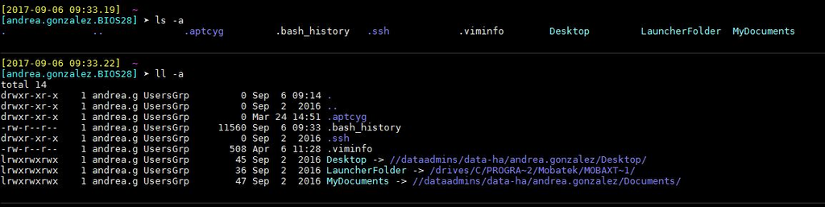

**Figura.** Listar **todos** los archivos en un directorio

NOTA: Para ver todas las opciones asociadas a los comandos **ls** y **ll**, ejecutar

```bash
ls --help
ll --help
```

## 1.4 Creando directorios

El comando **mkdir** (make directory) permite crear un directorio nuevo dentro de una ruta (por ejemplo, el home o cualquier otro directorio de trabajo actual). Para esta práctica, crearemos un directorio llamado “Practica”.

```bash
mkdir Practica
```

NOTA: En Linux, el uso de mayúsculas y minúsculas importa. No son equivalentes los directorios “Practica” que “practica” ni “PRACTICA”. Tambien, se debe evitar el uso de espacios al nombrar archivos y directorios, en su lugar, se deben usar otros caracteres como (_) (,) (;) (.) para separar palabras. Por ejemplo, para nombrar un nuevo directorio, se puede usar “Practica_1” en lugar de “Practica 1”, o “practica-curso-linux” y no “practica curso linux”. Tampoco se deben usar caracteres como tildes.

## 1.5 Cambiar de directorios

El comando **cd** (Change directory) permite cambiar de directorio, con el fin de moverse entre los directorios de trabajo, niveles arriba o niveles abajo.

Para entender y facilitar moverse entre directorios en la Terminal, es importante primero revisar la estructura o jerarquia de los directorios en Linux. Dicha estructura se representa en forma de árbol:

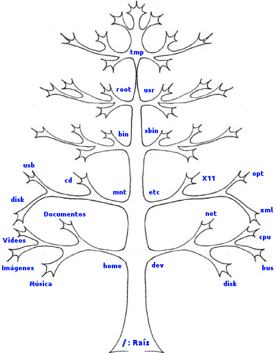

**Figura.** Estructura en forma de árbol de los directorios en Linux. La raíz del árbol **root** (simbolizado por /) es la base de toda la estructura de directorios y las ramas (directorios y archivos) surgen del root. Tomada de https://blog.desdelinux.net/estructura-de-directorios-en-linux/

Para consultar en detalle sobre los diferentes directorio en Linux, como / (root), /bin, /boot, /dev, /home, /lib, /usr, etc., referirse al siguiente link: http://www.linux-party.com/TutorialLinux/linux_files/jerarquia_sample.txt.

Aqui, cambiaremos de directorios al interior del home. Para esto, primero cambiaremos del home al directorio “Practica”" que creamos anteriormente

```bash
cd Practica
pwd
ls
```

Con los comandos anteriores, cambiamos del home al directorio Practica, luego imprimimos la ruta a ese directorio actual y listamos el contenido. Vemos que aun esta vacío.

Ahora, crearemos subdirectorios dentro de Practica

```bash
mkdir Dir_1
mkdir Dir_2
ls
```

Luego, cambiaremos al directorio Dir_1, crearemos un subdirectorio dentro de este y accederemos al nuevo directorio creado

```bash
#cd ./Dir_1
#pwd
#mkdir Dir_1.1
#ls
#cd Dir_1.1
#pwd
```

En resumen, hemos realizado lo siguiente :

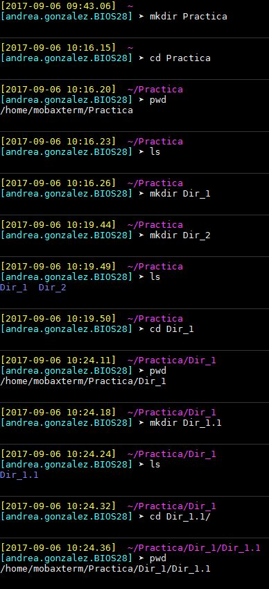

***

## 1.6 Cambiando de directorios con . y ..

En Linux, utilizamos . y .. para denotar dos lugares relativos al directorio actual de trabajo. El primero hace referencia al directorio actual (.) y el segundo al directorio parental (..) o directorio inmediatamente anterior que contiene el directorio actual. Podemos visualizar estos directorios de la siguiente manera

```bash
ls -a
```

[figure not shown]

**Figura.** Listando directorios . y ..

Estas dos sintaxis (. y ..) se utilizan para movernos tanto dentro del directorio actual como al inmediatamente anterior, de la siguiente manera

```bash
pwd
cd ..
pwd
cd ..
pwd
cd .
```

Con los comandos anteriores, subimos de niveles hasta regresar al directorio Practica, que contiene Dir_1 y Dir_1,1, que era donde nos ubicabamos inicialmente.

El comando “cd .” significa “en el directorio actual”.

## 1.7 Visualizando la estructura en árbol de directorios en Linux

Podemos visualizar la estructura en árbol de directorios que tenemos dentro de Practica utilizando el comando **tree**. Estando ubicados en el directorio Practica, ejecutamos el comando tree:

```bash
tree
```

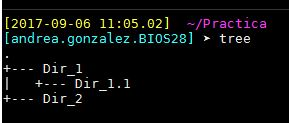

**Figura.** Visualizando la estructura en arbol de directorios con **tree**

Veamonos las estructuras en árbol de otros directorios de mayor nivel. Cambiemos al directorio home (~) y luego a / (root) y ejecutemos tree en cada uno.

```bash
cd ~
#alternativamente, si ejecutamos cd sin ningun argumento, también nos cambia al directorio home
cd
pwd
tree
cd /
pwd
tree
```

## 1.8 Rutas absolutas y rutas relativas

Una ruta o **PATH** es la ubicación única de un archivo o directorio al interior de un sistema de archivos. Es una combinación de / y caracteres alfa-numéricos.

Una **ruta absoluta** se define como la ruta de un archivo o directorio desde el directorio root (/). Por esta razón, es absoluta, ya que comienza desde la raíz del sistema de archivos. Por ejemplo, al ejecutar el comando **pwd** siempre nos arroja la ruta absoluta al directorio actual de trabajo, comenzando con (/).

Una **ruta relativa** se define como la ruta de un archivo o directorio relativo al directorio actual de trabajo. En este concepto, se utiliza entonces la sintaxis . y .. para navegar entre la estructura de directorios, siempre relativo al ultimo directorio de trabajo. Por tanto, estas rutas no comienzan con (/).

Podemos cambiar inmediatamente a cualquier directorio dentro del sistema de archivos desde cualquier otro directorio usando una ruta absoluta, asi se encuentren lejos en la estructura del árbol de directorios. Por otro lado, la ruta relativa es útil para movernos entre niveles cercanos, ahorrando tiempo y facilitando la navegación, siempre y cuando se tenga presente cual es el directorio actual de trabajo y como se ubican los demas directorios relativo a este.

Ejemplos:

```bash
pwd
#¿Donde estamos ubicados?
#Cambiemos al directorio Dir_1.1 con una ruta absoluta
cd /home/mobaxterm/Practica/Dir_1/Dir_1.1
pwd
#Cambiemos al directorio Practica con ruta relativa al directorio actual
cd ../..
pwd
#cambiemos a Dir_2 con ruta relativa al directorio actual
cd ./Dir_2
pwd
#Regresemos al directorio anterior especificando la ruta relativa y cambiemos de nuevo al Dir_2 utilizando la ruta absoluta
cd ..
cd /home/mobaxterm/Practica/Dir_2
```

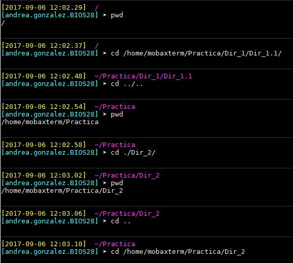

**Figura.** Cambiando de directorios usando rutas absolutas y relativas

# 2 Parte

## 2.1 Creando y guardando archivos

1. Editores de texto: **nano**, **gedit**, **vim**

Existen diferentes editores de texto para crear archivos en Linux: nano, gedit y vim. **Gedit** es diseñado como un editor de textos de propósito general, y enfatiza la simplicidad y facilidad de uso. **vim** es el editor de texto más potente de Linux en modo consola, pero no es muy amigable al usuario por su cantidad de atajos de teclado para su manejo en consola. Por otro lado, **nano** es intermedio entre los dos anteriores. En esta práctica nos enfocaremos en el uso de **nano**.

**Nano** viene instalado por defecto en Ubuntu. Cualquier usuario por poco experimentado que sea es capaz de empezar a usar **Nano** desde el primer momento gracias a las dos líneas de ayuda que mantiene en su parte inferior.

Para abrir un archivo con el editor nano se debe escribir el comando seguido del nombre del archivo con su extensión correspondiente. Si el archivo no esta en la ruta o en el directorio actual, entonces se debe especificar la ruta al archivo.

```bash
#Crearemos un archivo nuevo llamado file.txt usando nano
nano file.txt
```

Para escribir, se debe ubicar en la línea y posición en que desea, utlizando las flechas del teclado, e insertar el texto.

```bash
#Ahora, abriremos y editaremos el archivo existente lista.txt usando nano
nano lista.txt
```

**Nano** esta pensado para ser usado con el teclado, no con el ratón, por lo que cuenta con diferentes acciones asociadas a combinaciones de teclas. Al presionar la primera vez cada combinación de teclas se activa cada opciones y al hacerla una vez más se desactiva.

En la siguiente tabla podemos ver algunas de las más importantes:

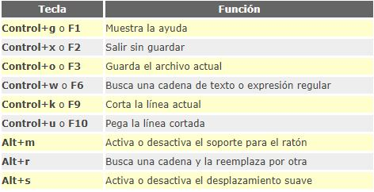

**Figura.** Acciones de teclado mas comunmente usadas en nano. Tomada de https://sliceoflinux.wordpress.com/2010/02/26/nano-sencillo-editor-de-textos-para-el-terminal/

Un dato que siempre es útil en un editor de texto es saber en que línea se encuentra y a veces en que columna se va a editar un texto o valor. Para poder ver esta información puedes iniciar el editor **nano** con el parámetro -c, al hacerlo podrá ver en que línea y columna se encuentra conforme se desplace en el texto mediante las teclas de flechas.

```bash
#Ahora, abriremos y editaremos el archivo existente lista.txt usando nano
nano -c lista.txt
```

Para pegar un texto previamente copiado de otra fuente, se usa la combinacion de teclas: **Ctrl+Shift+V**

Para grabar un archivo se usa la combinación de teclas: **Ctrl+o** (letra o). Presionar Enter, y listo.

Si no se desea grabar el archivo en ese momento, se puede cancelar esta accion con **Ctrl+c**

Alternativamente, para salir de **Nano**, se usa la siguiente combinación de teclas: **Ctrl+x** (y grabar el archivo si tiene alguna modificación) El editor permitirá verificar si desea guardar los cambios antes de salir. Debe responder Y (si) o N (no) y presionar Enter. Luego aparece una confirmación para conservar o cambiar el nombre del archivo.

Para más informacion sobre combinaciones de teclados y opciones de uso, ver https://www.nano-editor.org/dist/v2.8/nano.html.

2. **cat**

Alternativamente, se puede usar el comando **cat** (concatenate) para crear archivos de listas sencillas, como se muestra a continuación:

```bash
#Crearemos un archivo llamado lista.txt con el comando cat
cat > lista.txt
#Escribir los elementos de la lista a continuación
genoma
#Enter
transcriptoma
#Enter
proteoma
#Enter
metaboloma
#Enter
metagenoma
#Ctrl+C
ls
```

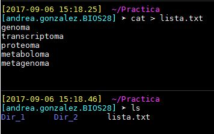

***

## 2.2 Lectura de archivos

1. **cat**

El comando **cat** también permite visualizar el contenido de archivos. Por ejemplo, visualicemos el archivo lista.txt, creado anteriormente:

```bash
cat lista.txt
```

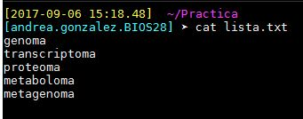

NOTA: Si el archivo tiene una extension de más de una página, este comando no será apropiado porque el contenido pasara de manera muy rápida por la pantalla hasta llegar a la última línea, como se podra observar con los siguientes archivo de ejemplo.

```bash
cat example_table.tsvc
cat example.fasta
```

2. **less** y **more**

Para archivos de larga extensión, los comandos **less** y **more** permiten visualizar el contenido de archivos por página.

```bash
less example_table.tsv
#Presione Enter para pasar a la siguiente línea. Presiona "b" para regresar a la página anterior. Escriba "q" para salir.
more example_table.tsv
#Presione Enter para pasar a la siguiente línea. Presione la barra de Espacio para ir a la siguiente pagina. Escriba "r" para ver todo el documento. Escriba "q" para salir.
#Visualice otro archivo de ejemplo.
less example.fasta
more example.fasta
```

El comando **less** tiene múltiples opciones para explorar un archivo. Por ejemplo, para regresar al comienzo del archivo se usa “g” y para ir al final se usa “G”. Para más opciones, consultar https://www.lifewire.com/what-to-know-less-command-4051972.

3. **head** y **tail**

Estos comandos imprimen las primeras (head) o últimas (tail) 10 líneas del archivo, de manera predeterminada. Si se desea visualizar una cantidad diferente de las primeras y últimas lieas, se utiliza la opcion **-n** antes del argumento.

```bash
head example_table.tsv
tail example_table.tsv
#Especifiquemos el parÃÂ¡metro -n para definir otro número de líneas a imprimir.
head -n 5 example_table.tsv
tail -n 5 example_table.tsv
```

## 2.3 Búsquedas dentro de archivos

1. **wc**

El comando **wc** (word count) permite contar las palabras, caracteres y líneas en un archivo.

```bash
wc --h
wc example_table.tsv
wc -l example_table.tsv
wc -w example_table.tsv
#Contemos las líneas en otro archivo de ejemplo.
wc -l example.fasta
```

2. **less**

Además de permitir visualizar el contenido de un archivo, **less** permite hacer búsquedas de contenidos especificos dentro del archivo, de la siguiente manera:

```bash
less example_table.tsv
#Escribir / y luego el tÃÂ©rmino a buscar
/ Howard
```

3. **grep**

Este comando es uno de los muchos que vienen predeterminados en Linux. Es poderoso para realizar búsquedas de palabras o patrones en archivos, donde el resultado impreso es la línea completa que contiene ese término de búsqueda.

```bash
grep --h
grep "Howard" example_table.tsv
#Miremos si la búsqueda es sensible a mayúsculas y minúsculas
grep "howard" example_table.tsv
#Contemos el número de líneas que contienen el término de búsqueda
grep -c "Howard" example_table.tsv
#Especifiquemos que imprima el número de la la línea donde encuentra el término de búsqueda
grep -n "Howard" example_table.tsv
#Especifiquemos que imprima las líneas que NO contienen el término de búsqueda (invertido)
grep -v "Howard" example_table.tsv
```

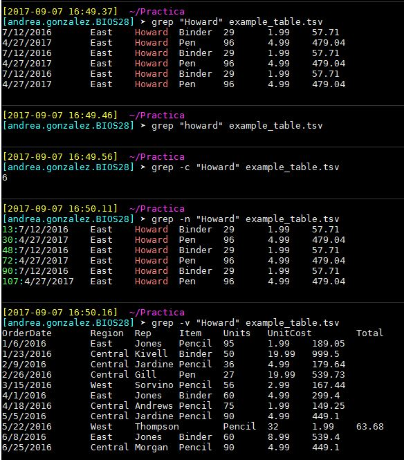

**Figura.** Busqueda de palabras o patrones en un archivo usando **grep**

Ahora, realicemos una búsqueda para varios términos simultáneamente, que estan contenidos en una lista.

```bash
#Creemos la lista de términos a buscar
cat > lista_grep.txt
Howard
Jones
Andrews
Thompson
#Ctrl+C
cat lista_grep.txt
#Busquemos los términos
fgrep -f lista_grep.txt example_table.tsv
```

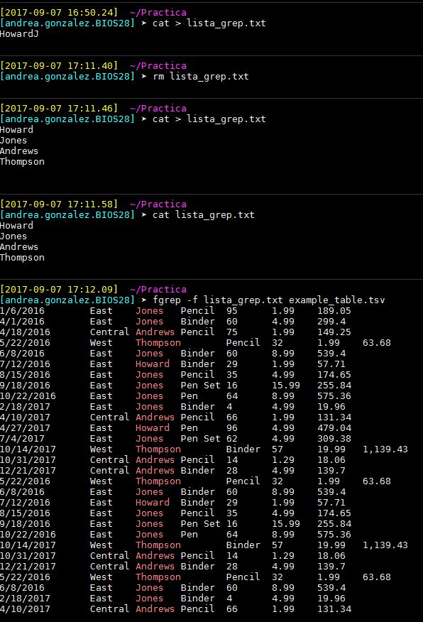

**Figura.** Búsqueda de palabras o patrones a partir de una lista usando **grep**

Ahora, aprendamos a redireccionar salidas, de tal manera que los resultados no se impriman en la Terminal, sino que se guarden en un archivo.

```bash
#Redireccionemos la salida de grep a un archivo nuevo
grep "Howard" example_table.tsv > search_results_table.tsv
less search_results_table.tsv
#Busquemos otro término y redireccionemoslo al mismo archivo anterior
grep "Jones" example_table.tsv > search_results_table.tsv
less search_results_table.tsv
#¿Qué paso con los resultados de la primera búsqueda?
#Para no sobreescribir, sino adicionar contenido a un archivo utilizamos ">>"
grep "Howard" example_table.tsv >> search_results_table.tsv
less search_results_table.tsv
```

## 2.4 Manipulación de archivos y directorios

1. Copiando con **cp**

El comando **cp** (copy) permite copiar archivos y directorios.

```bash
#Realicemos una copia del archivo lista.txt y llamemosla lista_2.txt
cp lista.txt lista_2.txt
less lista.txt
less lista_2.txt
ls
#Veamos que otra información sobre estos archivos nos sale especificando el comando ll
ll
ll -h
#Realicemos una copia del directorio Dir_1 con todo su contenido y llamemoslo Dir_1-copia. Para esto, necesitamos especificar la opcion "-r" que significa copia recursiva
cp -r Dir_1/ Dir_1-copia
ll
cd Dir_1-copia
ll
#Copiemos el directorio Dir_1.1 al directorio Dir_2 que estÃÂ¡ en Practica, un nivel más arriba de donde nos encontramos actualmente
cp -r Dir_1.1/ ../Dir_2/
cd ../Dir_2
ll
```

En resumen, hemos realizado lo siguiente, como se muestra en el pantallazo a continuación:

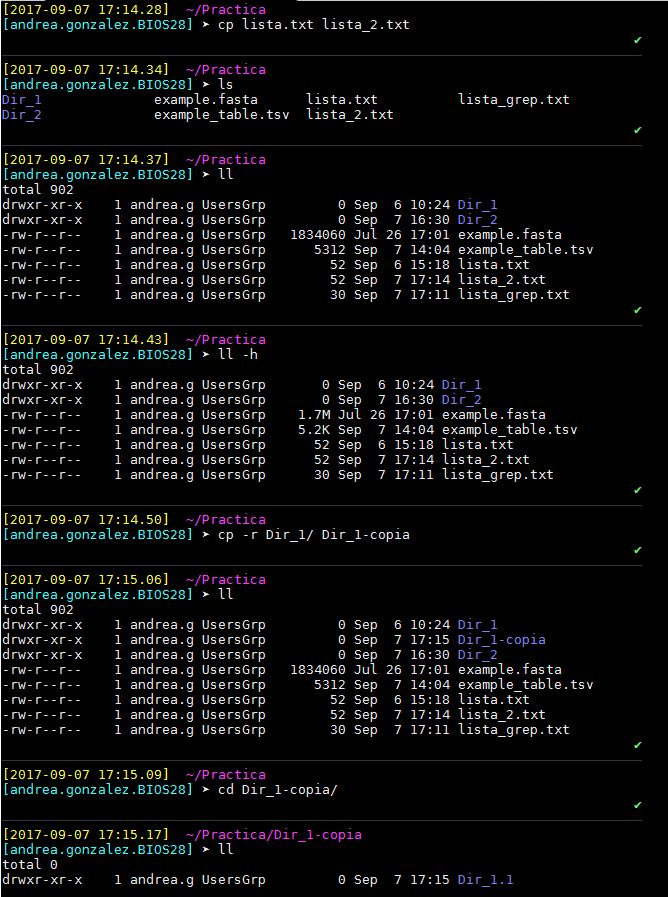

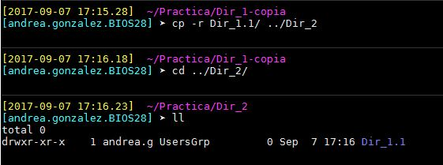

2. Moviendo y renombrando con **mv**

El comando **mv** (move) permite mover archivos y directorios.

```bash
#Regresemos al directorio Practica
cd ..
#Movamos el archivo lista.txt al directorio Dir_2
mv lista.txt ./Dir_2
cd ./Dir_2
ls
#Renombremos el archivo lista.txt a listado.txt
mv lista.txt listado.txt
ls
#Note que si no especifica una ruta como argumento, entonces mv servirá para renombrar el archivo
#Movamos el directorio Dir_1.1 al directorio Practica, un nivel más arriba de donde nos encontramos actualmente
mv Dir_1.1/ ../
cd ..
ll
#Renombremos el directorio Dir_1.1 a Dir_nuevo
mv Dir_1.1/ Dir_nuevo
ll
```

En resumen, hemos realizado lo siguiente, como se muestra en el pantallazo a continuación:

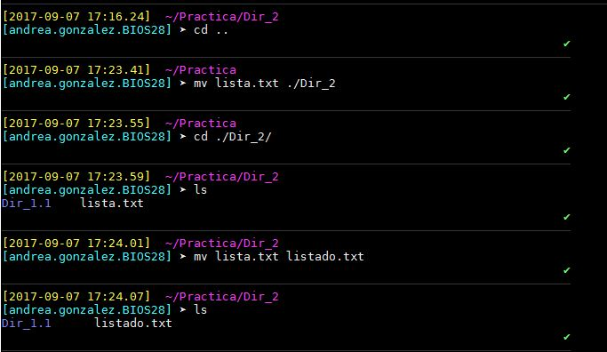

**Figura.** Moviendo y renombrando archivos y directorios usando **mv**

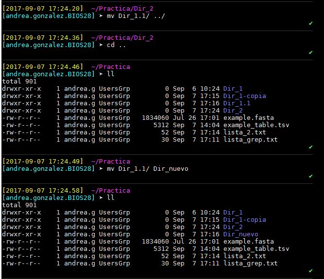

**Figura.** Continuación: Moviendo y renombrando archivos y directorios usando **mv**

3. Eliminando con **rm** y **rmdir**